# Identify and get missing diet information

# Summary

In this notebook we

- identify the species for which we have no prior information on their diet
- check for potential taxonomic issues that we will have to deal with
- use fishbase to get diet information

# 0. Setup

We load the environment.

```r
library(renv)
renv::load()

library(here)
library(stringr)
library(stringdist)
library(dplyr)
library(riversea)
library(rfishbase)
library(ggplot2)
```

Previous information on fish diet can be find on the dataframe hosted at the following address.

```r
url <- "https://raw.githubusercontent.com/CamilleLeclerc/FoodWebsLakeStream/refs/tags/v3.0/data/raw-data/fish_diet_shift.csv"
```

We download it and convert it to a dataframe.

```r
data_folder <- here("data", "river")
file_name <- "fish_diet.csv"
download.file(url, destfile = here(data_folder, file_name))
```

We can check that the file has been downloaded.

```r
list.files(data_folder, pattern = file_name)
```

```
[1] "fish_diet.csv"
```

We then read the file as a dataframe.

```r
d.diet <- read.csv(here(data_folder, file_name))
sp_list.diet <- sort(unique(d.diet$species_name))
sp_list.diet <- str_replace(sp_list.diet, "_", " ")
sp_list.diet
```

```
 [1] "Abramis brama"               "Acipenser ruthenus"
 [3] "Alburnoides bipunctatus"     "Alburnus alburnus"
 [5] "Ameiurus melas"              "Anguilla anguilla"
 [7] "Aspius aspius"               "Barbatula barbatula"
 [9] "Barbus barbus"               "Barbus meridionalis"
[11] "Blicca bjoerkna"             "Carassius auratus"
[13] "Carassius carassius"         "Carassius gibelio"
[15] "Chelon auratus"              "Chelon ramada"
[17] "Chondrostoma nasus"          "Chondrostoma toxostoma"
[19] "Cobitis taenia"              "Coregonus lavaretus"
[21] "Cottus gobio"                "Cottus petiti"
[23] "Cyprinus carpio"             "Esox lucius"
[25] "Gambusia affinis"            "Gasterosteus aculeatus"
[27] "Gobio gobio"                 "Gymnocephalus cernua"
[29] "Hypophthalmichthys molitrix" "Lepomis gibbosus"
```

[output cut: 16 more lines]

# 1. Pomet

To identify missing species in this dataframe, we have to load dataframes from sea campagne (solper, pomet, nurse).

```r
data_folder <- here("data", "sea", "raw")
pomet <- read.csv(here(data_folder, "poisson_pomet.csv"), sep = ";")
solper <- read.csv(here(data_folder, "captures_SOLPER_2005_2011.csv"), sep = ";")
nurse <- read.csv(here(data_folder, "Captures_Nurse_1980_2023.csv"), sep = ";")

sp_pomet <- unique(pomet$NomScient)
head(sp_pomet)
```

```
[1] "Abramis"                         "Abramis brama"
[3] "Abramis brama + Blicca bjoerkna" "Acipenser sturio"
[5] "Agonus cataphractus"             "Alburnoides bipunctatus"
```

```r
sp_solper <- unique(solper$Espece)
head(sp_solper)
```

```
[1] "CALMLYR" "ENGRENC" "GOBINIG" "POMOMIN" "SOLESOL" "SPRASPR"
```

```r
sp_nurse <- unique(nurse$Espece)
head(sp_nurse)
```

```
[1] "Anguilla anguilla"  "Crangon crangon"    "Platichthys flesus"
[4] "Solea solea"        "Trisopterus luscus" "Ciliata mustela"
```

```r
reftax_file <- "POMET_RefTax_Sp.csv"
reftax <- read.csv(here(data_folder, reftax_file), sep = ";")
```

## 1.1. Handle taxonomic resolutions: keep only species

```r
is_species <- function(name) grepl(" ", name)
species_only <- sp_pomet[is_species(sp_pomet)]
```

## 1.2. Handle different genres: keep only fish

```r
remove_non_fish <- function(species_list, reftax) {
    sp_df <- data.frame(nom = species_list)
    sp_df <- left_join(sp_df, reftax, by = "nom")
    sp_df <- sp_df |> filter(phylum == "Chordata" | is.na(phylum))
    sp_df$nom
}

fish_only <- remove_non_fish(species_only, reftax)
species_missing <- setdiff(fish_only, sp_list.diet)
species_missing
```

```
  [1] "Abramis brama + Blicca bjoerkna"
  [2] "Acipenser sturio"
  [3] "Agonus cataphractus"
  [4] "Alosa alosa"
  [5] "Alosa fallax"
  [6] "Ammodytes marinus"
  [7] "Ammodytes tobianus"
  [8] "Aphia minuta"
  [9] "Apletodon dentatus"
 [10] "Argyrosomus regius"
 [11] "Arnoglossus imperialis"
 [12] "Arnoglossus laterna"
 [13] "Arnoglossus thori"
 [14] "Atherina boyeri"
 [15] "Atherina presbyter"
```

[output cut: 120 more lines]

## 1.3. Handle taxonomic typos

Next, we want to check for mismatch because of typos or alternative taxonomic names. To do so, we compute a string distance to find species with most similar names between our two lists. By doing so, we will be able to quickly identify erroneous mismatch.

```r
similar_name <- lapply(species_missing, function(name) {
    distances <- stringdist(name, sp_list.diet, method = "jw")
    closest <- sp_list.diet[which.min(distances)]
    data.frame(name = name, closest = closest, distance = min(distances))
})

df_strdist <- do.call(rbind, similar_name) |>
    arrange(distance)
df_strdist
```

```
                                   name                    closest   distance
1           Scardinius erythrophthalmus Scardinius erythrophtalmus 0.01234568
2                 Gymnocephalus cernuus       Gymnocephalus cernua 0.04841270
3                  Barbatula barbatulus        Barbatula barbatula 0.05087719
4      Gasterosteus aculeatus aculeatus     Gasterosteus aculeatus 0.10416667
5                      Acipenser sturio         Acipenser ruthenus 0.16335979
6       Abramis brama + Blicca bjoerkna              Abramis brama 0.19354839
7                       Chelon labrosus             Chelon auratus 0.20577201
8                       Clupea harengus             Chelon auratus 0.21150794
9                Myoxocephalus scorpius       Gymnocephalus cernua 0.22121212
10                     Taurulus bubalis          Alburnus alburnus 0.23067496
11                    Sander lucioperca    Stizostedion lucioperca 0.24404660
12                Merluccius merluccius        Leuciscus leuciscus 0.24657999
13                         Salaria pavo        Salaria fluviatilis 0.24678363
14                       Labrus viridis        Barbus meridionalis 0.25375940
```

[output cut: 121 more lines]

We see that there are few issues

- Typo for the Scardinius erythro. in the diet species list.
- Outdated taxonomic name for Gymnocephalus cernua.
- Subspecies resolution for Gasterosteus aculeatus.
- Two species in one for Abramis brama + Blicca bjoerkna.
- Outdated taxonomic name for Trutta fario.

```r
species_to_remove <- c(
    "Abramis brama + Blicca bjoerkna"
)
species_missing <- species_missing[!(species_missing %in% species_to_remove)]
```

Actually, we can use fishbase for taxonomic issues. Instead of working with raw names, we can ensure that we have validated names, using fishbase functions.

```r
name_diet <- data.frame(original = sp_list.diet)
name_diet$validated <- validate_names(sp_list.diet)

name_diet |> filter(original != validated)
```

```
                    original                   validated
1              Aspius aspius            Leuciscus aspius
2     Chondrostoma toxostoma  Parachondrostoma toxostoma
3         Leuciscus cephalus           Squalius cephalus
4         Pachychilon pictus          Pachychilon pictum
5        Salaria fluviatilis     Salariopsis fluviatilis
6 Scardinius erythrophtalmus Scardinius erythrophthalmus
7    Stizostedion lucioperca           Sander lucioperca
8               Trutta fario                Salmo trutta
```

```r
name_missing <- data.frame(original = species_missing)
name_missing$validated <- validate_names(name_missing$original)

name_missing |> filter(original != validated)
```

```
                              original                 validated
1                 Barbatula barbatulus       Barbatula barbatula
2  Diplecogaster bimaculata bimaculata  Diplecogaster bimaculata
3               Diplodus sargus sargus           Diplodus sargus
4     Gasterosteus aculeatus aculeatus    Gasterosteus aculeatus
5               Gobiusculus flavescens Pomatoschistus flavescens
6                Gymnocephalus cernuus      Gymnocephalus cernua
7              Liparis liparis liparis           Liparis liparis
8                          Liza aurata            Chelon auratus
9                          Liza ramada             Chelon ramada
10            Mullus barbatus barbatus           Mullus barbatus
11                  Salmo trutta fario              Salmo trutta
12                 Salmo trutta trutta              Salmo trutta
13               Trigloporus lastoviza Chelidonichthys lastoviza
```

```r
missing_pomet <- setdiff(name_missing$validated, name_diet$validated)
length(missing_pomet)
```

```
[1] 124
```

## 1.4. Rare species

Next, we want to compute average abundance for these species to identify potential rare species that wouldn’t be interesting to include.

```r
abundance_pomet <- pomet |>
    filter(NomScient %in% missing_pomet) |>
    group_by(NomScient) |>
    summarise(n = sum(Nind_esp)) |>
    arrange(n)
head(abundance_pomet)
```

```
# A tibble: 6 × 2
  NomScient                     n
  <chr>                     <int>
1 Belone belone                 1
2 Crystallogobius linearis      1
3 Diplodus vulgaris             1
4 Gobius cobitis                1
5 Lepadogaster lepadogaster     1
6 Mustelus asterias             1
```

```r
abundance_rank <- abundance_pomet |>
    group_by(n) |>
    summarise(count = n())
head(abundance_rank)
```

```
# A tibble: 6 × 2
      n count
  <int> <int>
1     1    13
2     2     4
3     3     5
4     4     2
5     5     1
6     6     5
```

```r
n_min <- 20 # Minimal abundance to be included.
rare_pomet <- abundance_pomet |>
    filter(n <= n_min) |>
    pull(NomScient)
length(rare_pomet)
```

```
[1] 44
```

```r
missing_pomet <- name_missing |>
    filter(validated %in% missing_pomet) |>
    filter(!original %in% rare_pomet) |>
    pull(validated)
```

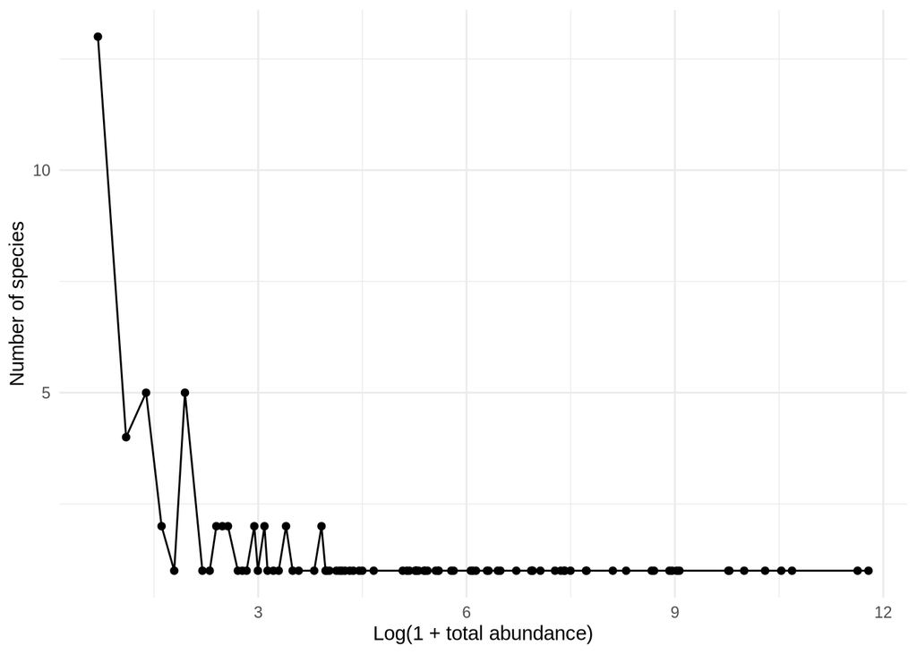

```r
set_theme(theme_minimal())
ggplot(abundance_rank, aes(x = log(1 + n), y = count)) +
    geom_line() +
    geom_point() +
    labs(x = "Log(1 + total abundance)", y = "Number of species")
```

# 2. Nurse

```r
length(sp_nurse)
```

```
[1] 625
```

We see that we have many species. This probably means that we have many non-fish species that we will have to remove. First, we remove genus to only keep species names.

```r
species_only <- sp_nurse[is_species(sp_nurse)]
length(species_only)
```

```
[1] 441
```

Next, we want to remove non-fish species. We load the corresponding reftax table.

```r
list.files(data_folder)
```

```
 [1] "Captures_Nurse_1980_2023.csv"
 [2] "captures_SOLPER_2005_2011.csv"
 [3] "environment"
 [4] "fish_diet.csv"
 [5] "lifestage_size.csv"
 [6] "MATURITYsummary.Rdata"
 [7] "poisson_pomet.csv"
 [8] "poisson_tailles_pomet.csv"
 [9] "POMET_RefTax_Sp.csv"
[10] "Reftax_Captures_NURSE_DCE_SUIVINOUR_SOLPER_2024.RData"
[11] "Reftax_SIH.txt"
[12] "Strates_Nurse_1980_2023.csv"
[13] "strates_SOLPER_2005_2011.csv"
[14] "Tailles_Nurse_1980_2023.csv"
[15] "tailles_SOLPER_2005_2011.csv"
[16] "Traits_Nurse_1980_2023.csv"
[17] "traits_SOLPER_2005_2011.csv"
```

```r
reftax_file <- list.files(data_folder, pattern = "RData")[1]
load(here(data_folder, reftax_file))
reftax <- ESPECE_MAJ
```

```r
sp_df <- data.frame(scientificname = species_only)
sp_df <- sp_df |>
    left_join(reftax, by = "scientificname") |>
    filter(phylum == "Chordata" | is.na(phylum)) |>
    filter(class == "Teleostei" | class == "Elasmobranchii" | is.na(class))
fish_only <- sp_df$scientificname

name_nurse <- data.frame(original = fish_only)
name_nurse$validated <- validate_names(name_nurse$original)
name_nurse |> filter(original != validated)
```

```
     original      validated
1 Liza ramada  Chelon ramada
2 Liza aurata Chelon auratus
```

```r
missing_nurse <- setdiff(name_nurse$validated, name_diet$validated)
length(missing_nurse)
```

```
[1] 101
```

```r
abundance_nurse <- nurse |>
    filter(Espece %in% missing_nurse) |>
    group_by(Espece) |>
    summarise(n = sum(Nombre, na.rm = TRUE)) |>
    arrange(n)
head(abundance_nurse)
```

```
# A tibble: 6 × 2
  Espece                       n
  <chr>                    <int>
1 Parablennius gattorugine     0
2 Dasyatis pastinaca           1
3 Diplodus sargus              1
4 Lithognathus mormyrus        1
5 Lophius budegassa            1
6 Microstomus kitt             1
```

```r
rare_nurse <- abundance_nurse |>
    filter(n <= n_min) |>
    pull(Espece)
length(rare_nurse)
```

```
[1] 39
```

```r
missing_nurse <- name_nurse |>
    filter(original %in% missing_nurse) |>
    filter(!validated %in% rare_nurse) |>
    pull(validated)
length(missing_nurse)
```

```
[1] 61
```

```r
missing_all <- sort(unique(c(missing_nurse, missing_pomet)))
missing_all
```

```
 [1] "Agonus cataphractus"        "Alosa alosa"
 [3] "Alosa fallax"               "Ammodytes tobianus"
 [5] "Aphia minuta"               "Argyrosomus regius"
 [7] "Arnoglossus laterna"        "Arnoglossus thori"
 [9] "Atherina boyeri"            "Atherina presbyter"
[11] "Buglossidium luteum"        "Callionymus lyra"
[13] "Centrolabrus exoletus"      "Chelidonichthys cuculus"
[15] "Chelidonichthys lastoviza"  "Chelidonichthys lucerna"
[17] "Chelon labrosus"            "Ciliata mustela"
[19] "Clupea harengus"            "Conger conger"
[21] "Ctenolabrus rupestris"      "Dicentrarchus labrax"
[23] "Dicentrarchus punctatus"    "Dicologlossa cuneata"
[25] "Diplecogaster bimaculata"   "Diplodus annularis"
[27] "Diplodus sargus"            "Echiichthys vipera"
[29] "Engraulis encrasicolus"     "Engraulis maeoticus"
```

[output cut: 31 more lines]

# 3. Solper

```r
length(sp_solper)
```

```
[1] 59
```

For Solper, we have code instead of species names.

```r
head(sp_solper)
```

```
[1] "CALMLYR" "ENGRENC" "GOBINIG" "POMOMIN" "SOLESOL" "SPRASPR"
```

**Warning**

I cannot find the relation between species code and their scientific name.

# 4. Get diet data from fishbase

## 4.1. Missing species from sea campagnes

Now that we have a species list for which we want to get their diet we can scrap fishbase.

Because this step is crucial and is expected to be repeated we implement it directly in our package `riversea`.

So we can directly obtain diet for all species with a single function call.

```r
diet_category <- get_diet_category(missing_all)
head(diet_category)
```

```
# A tibble: 6 × 3
  species             stage       prey_category
  <chr>               <chr>       <chr>
1 Agonus cataphractus adults      crustacean
2 Agonus cataphractus adults      worm
3 Alosa alosa         adults      fish
4 Alosa alosa         juv./adults fish
5 Alosa alosa         juv./adults crustacean
6 Alosa alosa         juv./adults zooplankton
```

Next, to obtain something similar as the table for riverine fish, we can also extract a wide table.

```r
diet_category_wide <- get_diet_category_wide(missing_all)
head(diet_category_wide)
```

```
# A tibble: 6 × 12
  species      stage biofilm crustacean detritus echinoderm  fish insect mollusk
  <chr>        <chr>   <dbl>      <dbl>    <dbl>      <dbl> <dbl>  <dbl>   <dbl>
1 Agonus cata… adul…       0          1        0          0     0      0       0
2 Alosa alosa  recr…       0          0        0          0     0      1       0
3 Alosa alosa  juv.…       0          1        0          0     1      0       0
4 Alosa alosa  adul…       0          0        0          0     1      0       0
5 Alosa fallax recr…       0          0        0          0     0      0       0
6 Alosa fallax juv.…       0          1        1          0     1      1       1
# ℹ 3 more variables: phytoplankton <dbl>, worm <dbl>, zooplankton <dbl>
```

## 4.2. Fishbase diet for riverine fish

```r
diet_category <- get_diet_category(name_diet$validated)
head(diet_category)
```

```
# A tibble: 6 × 3
  species       stage  prey_category
  <chr>         <chr>  <chr>
1 Abramis brama adults detritus
2 Abramis brama adults fish
3 Abramis brama adults insect
4 Abramis brama adults crustacean
5 Abramis brama adults worm
6 Abramis brama adults zooplankton
```

```r
diet_category_wide <- widen_diet_category(diet_category)
head(diet_category_wide)
```

```
# A tibble: 6 × 12
  species      stage biofilm crustacean detritus  fish insect macrophyte mollusk
  <chr>        <chr>   <dbl>      <dbl>    <dbl> <dbl>  <dbl>      <dbl>   <dbl>
1 Abramis bra… recr…       0          1        0     0      1          0       0
2 Abramis bra… juv.…       0          1        1     0      1          1       1
3 Abramis bra… adul…       0          1        1     1      1          0       0
4 Acipenser r… juv.…       0          0        0     0      1          0       0
5 Alburnoides… juv.…       0          1        0     0      1          0       0
6 Alburnus al… juv.…       1          1        1     0      1          0       0
# ℹ 3 more variables: phytoplankton <dbl>, worm <dbl>, zooplankton <dbl>
```

```r
write.csv(diet_category_wide, here("data", "fishbase_diet_river.csv"))
```

Let’s focus on a single species *Abramis brama*

```r
diet_category_wide |> filter(species == "Abramis brama")
```

```
# A tibble: 3 × 12
  species      stage biofilm crustacean detritus  fish insect macrophyte mollusk
  <chr>        <chr>   <dbl>      <dbl>    <dbl> <dbl>  <dbl>      <dbl>   <dbl>
1 Abramis bra… recr…       0          1        0     0      1          0       0
2 Abramis bra… juv.…       0          1        1     0      1          1       1
3 Abramis bra… adul…       0          1        1     1      1          0       0
# ℹ 3 more variables: phytoplankton <dbl>, worm <dbl>, zooplankton <dbl>
```

and compare with the original table that we have downloaded.

```r
d.diet |> filter(species_name == "Abramis_brama")
```

```
  species  species_name size_min size_max stage light det biof phytob macroph
1     BRE Abramis_brama      0.0      9.7     1     0   0    0      0       0
2     BRE Abramis_brama      9.8     17.0     2     0   0    0      0       0
3     BRE Abramis_brama     17.1    120.0     3     0   0    1      1       0
4     BRE Abramis_brama    120.1      Inf     4     0   0    1      1       0
  phytopl zoopl zoob fish                 ref_diet                  ref_ods
1       1     1    0    0                 Nunn2012               Garner1996
2       0     1    0    0                 Nunn2012               Garner1996
3       0     1    0    0               Garner1996 Persson1998/Specziar2009
4       0     0    1    0 Persson1998/Specziar2009                     <NA>
           hypoth_ods                           remark
1 maximum size hypoth ! Bream eats chironomids = zoob_
2 minimum size hypoth ! Bream eats chironomids = zoob_
3         litterature ! Bream eats chironomids = zoob_
4         litterature             eats benthic daphnia
```

## 4.3. All species

```r
name_diet$validated
```

```
 [1] "Abramis brama"               "Acipenser ruthenus"
 [3] "Alburnoides bipunctatus"     "Alburnus alburnus"
 [5] "Ameiurus melas"              "Anguilla anguilla"
 [7] "Leuciscus aspius"            "Barbatula barbatula"
 [9] "Barbus barbus"               "Barbus meridionalis"
[11] "Blicca bjoerkna"             "Carassius auratus"
[13] "Carassius carassius"         "Carassius gibelio"
[15] "Chelon auratus"              "Chelon ramada"
[17] "Chondrostoma nasus"          "Parachondrostoma toxostoma"
[19] "Cobitis taenia"              "Coregonus lavaretus"
[21] "Cottus gobio"                "Cottus petiti"
[23] "Cyprinus carpio"             "Esox lucius"
[25] "Gambusia affinis"            "Gasterosteus aculeatus"
[27] "Gobio gobio"                 "Gymnocephalus cernua"
[29] "Hypophthalmichthys molitrix" "Lepomis gibbosus"
```

[output cut: 16 more lines]

```r
validate_names("Abramis brama")
```

```
[1] "Abramis brama"
```

```r
name_all <- data.frame(original = name_diet$original, validated = name_diet$validated, campagne = "river")

n_nurse <- unique(nurse$Espece)
name_nurse <- data.frame(original = n_nurse, validate_names(n_nurse), campagne = "nurse")

n_pomet <- unique(pomet$NomScient)
name_pomet <- data.frame(original = n_pomet, validate_names(n_pomet), campagne = "pomet")

unique(nurse$Espece)
```

```
  [1] "Anguilla anguilla"
  [2] "Crangon crangon"
  [3] "Platichthys flesus"
  [4] "Solea solea"
  [5] "Trisopterus luscus"
  [6] "Ciliata mustela"
  [7] "Liza ramada"
  [8] "Osmerus eperlanus"
  [9] "Merlangius merlangus"
 [10] "Dicentrarchus labrax"
 [11] "Sprattus sprattus"
 [12] "Clupea harengus"
 [13] "Pleuronectes platessa"
 [14] "Trachurus trachurus"
 [15] "Atherina presbyter"
```

[output cut: 610 more lines]

# 5. AquaticWeb

Let’s load the combined dataset.

```r
library(tidyr)
tidy_data <- load_raw_sea_data(here("data", "sea", "raw")) |>
    clean_sea_data() |>
    combine_sea_data()

species_names <- tidy_data$catch |>
    pull(species) |>
    unique()
species <- data.frame(name = species_names)

species$name_validated <- validate_names(species$name)

head(species)
```

```
                             name          name_validated
1                         Abramis                    <NA>
2                   Abramis brama           Abramis brama
3 Abramis brama + Blicca bjoerkna                    <NA>
4                Acipenser sturio        Acipenser sturio
5             Agonus cataphractus     Agonus cataphractus
6         Alburnoides bipunctatus Alburnoides bipunctatus
```

```r
aquatic_web <- read.csv(here("data", "diet", "aquatic-web-extraction-eric.csv"))
head(aquatic_web)
```

```
           predateur         proie mange selectivity nom origine stade_pred
1 Salvelinus alpinus       Daphnia    -1           3
2         Polyarthra Cryptophyceae    -1           3
3         Polyarthra Chrysophyceae    -1           3
4         Cyclopoida  Chironomidae    -1          -1
5         Cyclopoida     Cladocera    -1          -1
6         Cyclopoida      Rotifera    -1          -1
  stade_proie                                                         titre
1             Zooplankton and its relation to available food in Lake Myvatn
2             Zooplankton and its relation to available food in Lake Myvatn
3             Zooplankton and its relation to available food in Lake Myvatn
4       Larve Zooplankton and its relation to available food in Lake Myvatn
5             Zooplankton and its relation to available food in Lake Myvatn
6             Zooplankton and its relation to available food in Lake Myvatn
  num_vol numero_article DOI annee nom.1          journal
1      32                     1979 Oikos Adelsteinsson H.
2      32                     1979 Oikos Adelsteinsson H.
3      32                     1979 Oikos Adelsteinsson H.
4      32                     1979 Oikos Adelsteinsson H.
5      32                     1979 Oikos Adelsteinsson H.
6      32                     1979 Oikos Adelsteinsson H.
```

```r
names_aquatic_web <- aquatic_web |>
    pull(predateur) |>
    unique() |>
    validate_names() |>
    na.omit()

species <- species |>
    mutate(in_aquatic_web = name_validated %in% names_aquatic_web)

species |> summarise(
    unique_entry = n(),
    valid_entry = sum(!is.na(name_validated)),
    aquatic_web_entry = sum(in_aquatic_web)
)
```

```
  unique_entry valid_entry aquatic_web_entry
1          790         184                64
```

## TODO

- Do the diet table for fish already documented and compare diet.